# What changes when we link claims and EHR?

Debasrija

2026-10-27

**Plan (written before analysis, 2026-10-27).** Cohorts: Baseline, age 66 and above - EHR+claims data (crosswalk-joined) for 365 days lookback from index date, Capture: Baseline (nested) also observed through 365 days post index date using effective end. Treatment (Capture): code_map “treatment”, days 0-365 both inclusive, describe statistics overall and for different modalities. Report claims/EHR/either linked proportions + Wilson’s CI, treating groups as paired. Describe the agreement between either source. Mortality (Baseline): death by day 365, all-cause, Wilson’s CI. Assess data reliability and log it.

## 1. Cohorts

Table 1. Cohort flow from the 800-patient roster.

| Step | Cohort | Remaining | Excluded |
| --- | --- | --- | --- |
| Roster |  | 800 |  |
| Age >= 66 |  | 675 | 125 |
| Lookback in both claims+EHR | Baseline cohort (mortality) | 501 | 174 |
| Follow-up to day 365 in both claims+EHR | Capture cohort (treatment) | 375 | 126 |

Mortality comes from the shared registry, so it needs only pre-index observation (baseline cohort, n = 501). Treatment can only be recorded while a source is observing, so the capture cohort additionally requires both sources’ effective end (earliest of recorded end, death, 2023-12-31) on or after day 365. Of the 126 patients removed at that step, 18 died before day 365; the rest lost observation in at least one source.

## 2. Treatment capture

Table 2. Treatment recorded on days 0-365, capture cohort. 95% CI: Wilson score.

| View | Treated | Patients | % | 95% CI low | 95% CI high |
| --- | --- | --- | --- | --- | --- |
| Claims | 153 | 375 | 40.8 | 35.9 | 45.8 |
| EHR | 144 | 375 | 38.4 | 33.6 | 43.4 |
| Linked (either) | 163 | 375 | 43.5 | 38.5 | 48.5 |

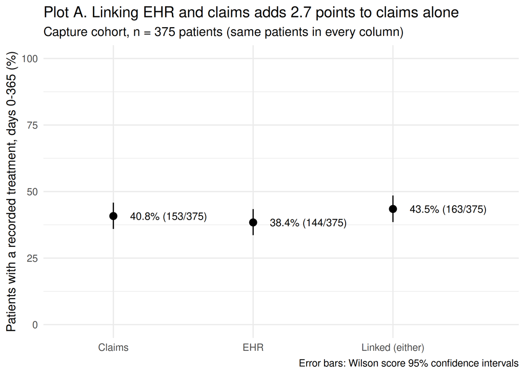

Claims recorded treatment for 40.8% and the EHR for 38.4%; linking raised this to 43.5%. Of 375 patients, 134 had treatment in both sources, 19 in claims only, 10 in the EHR only and 212 in neither. The linked-minus-claims difference (2.7 points) is exactly the EHR-only share, so its Wilson interval (1.5 to 4.8) is the interval for the gain from linkage.

The three figures describe the same patients, so they should not be read as independent groups. Claims-only records were surgery, radiation and injected ADT, consistent with care outside the EHR’s health system. Of 10 EHR-only patients, 9 lacked Part D and had only oral ADT, which claims cannot see; 1 had surgery missing from claims despite Part D (unexplained; possibly a billing gap).

## 3. Initial treatment patterns

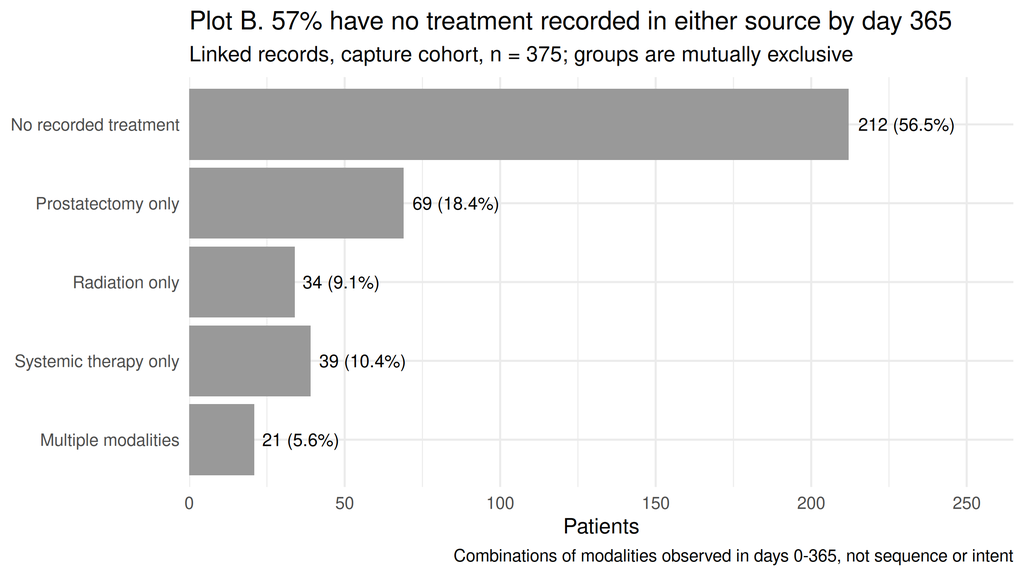

In linked records, 212 of 375 patients (56.5%) had no treatment recorded by day 365, plausibly reflecting active surveillance or watchful waiting in older men, though some treatment may be missing from both sources. Prostatectomy alone was the most common modality (69), and 21 patients had two or more. These are combinations observed within the year, not sequence, switching or intent.

## 4. 365-day all-cause mortality

Table 3. 365-day all-cause mortality from diagnosis (index date), baseline cohort. Deaths on days 0-365 inclusive; 95% CI: Wilson score.

| Endpoint | Cohort | Denominator | Deaths | % | 95% CI low | 95% CI high |
| --- | --- | --- | --- | --- | --- | --- |
| All-cause death, days 0-365 after diagnosis (registry) | Baseline cohort | 501 | 20 | 4.0 | 2.6 | 6.1 |

20 of 501 baseline patients died within 365 days (4.0%). The capture cohort would be the wrong denominator: it excludes anyone whose death truncated observation before day 365, leaving only 2 deaths that fell exactly on day 365 (0.5%). Mortality is not compared across treatment-pattern groups, since being treated requires surviving long enough (immortal-time bias).

## 5. Fitness for purpose

In the capture cohort, median baseline PSA among valid values was 8.64 ng/mL; PSA was missing for 62 (16.5%) and grade group for 104 (27.7%), including one invalid value (7) recoded as missing. Missing values were not imputed.

Treatment can be missed in three ways. **Care outside the EHR’s health system** is invisible to the EHR; the 19 claims-only patients show this happens. **No Part D** (109 capture patients) hides oral ADT from claims; injected ADT remains visible. **Care in neither extract** cannot be measured here, so the linked 43.5% likely underestimates the true proportion treated.

What we measured: agreement between sources, and which patients lack a recorded grade. We can only reason about treatment absent from both sources, and generalisation beyond fee-for-service Medicare men aged 66+. Eligibility rules also select patients: requiring 365 days of follow-up removed early deaths and patients who left either source. The Wilson intervals reflect sampling variation only; within this synthetic extract the proportions are exact, and the intervals do not account for systematic under-capture.

## 6. Extension: is a missing grade group random?

Table 4. Grade missing by age (baseline cohort) and treatment, linked days 0-365, by grade (capture cohort). 95% CI: Wilson score.

|  | Group | Patients | Count | % | 95% CI low | 95% CI high |
| --- | --- | --- | --- | --- | --- | --- |
| Grade missing, by age (baseline cohort) | 66-70 | 135 | 38 | 28.1 | 21.2 | 36.3 |
| Grade missing, by age (baseline cohort) | 71-75 | 153 | 34 | 22.2 | 16.4 | 29.4 |
| Grade missing, by age (baseline cohort) | 76-80 | 128 | 28 | 21.9 | 15.6 | 29.8 |
| Grade missing, by age (baseline cohort) | 81+ | 85 | 32 | 37.6 | 28.1 | 48.3 |
| Treated, by grade (capture cohort) | Grade 1 | 61 | 19 | 31.1 | 20.9 | 43.6 |
| Treated, by grade (capture cohort) | Grade 2 | 72 | 20 | 27.8 | 18.8 | 39.0 |
| Treated, by grade (capture cohort) | Grade 3 | 62 | 26 | 41.9 | 30.5 | 54.3 |
| Treated, by grade (capture cohort) | Grade 4 | 54 | 34 | 63.0 | 49.6 | 74.6 |
| Treated, by grade (capture cohort) | Grade 5 | 22 | 17 | 77.3 | 56.6 | 89.9 |
| Treated, by grade (capture cohort) | Missing | 104 | 47 | 45.2 | 36.0 | 54.8 |

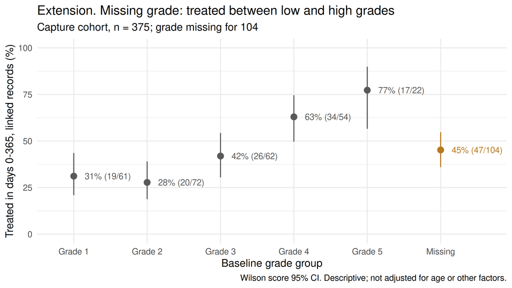

**Question:** grade was missing for 104 capture patients (27.7%). Are they treated like the least favourable grades? The brief defines no “low” or “high” cut-point, so grades are shown separately. Treatment rose with grade, from 31.1% (grade 1) to 77.3% (grade 5). Missing-grade patients were treated 45.2% of the time (36.0 to 54.8): between grades 1-2 and 4-5 (63.0% and 77.3% for 4-5), closest to grade 3 (41.9%), with intervals overlapping grades 1-3. Dropping them, or assuming any single grade, could bias grade-based analyses.

Who is missing it is less clear. In the baseline cohort, missingness was highest in men 81+ (37.6%, 28.1 to 48.3), with overlapping intervals across age groups.

**Alternative readings:** older men may lack a gradable biopsy; the grade may sit in another provider’s record; comparisons are unadjusted and some groups small.

**Limitation and next step:** I ran out of time to test robustness. Next I would run sensitivity analyses (each source alone, Part D patients only, age 80 or under vs 81+, a different-length window eg. 180 days) and adjust for age.

## Reproducibility

Reproducibility record, generated at render time.

| Item | Value |
| --- | --- |
| Raw files matching CHECKSUMS.sha256 | 7 of 7 |
| R version | R version 4.6.0 (2026-04-24) |
| Rendered | 2026-10-28 19:17 |

Automated checks; code in R/03-tests.R. Any failure stops the pipeline.

| Automated check (run on the real data) | Result |
| --- | --- |
| Linkage: no ID is missing or repeated in the crosswalk | PASS |
| Linkage: roster and crosswalk contain the same patients | PASS |
| Linkage: every event row matched the crosswalk (none lost in the join) | PASS |
| Linkage: the joined patient table has one row per roster patient | PASS |
| Window: all 2 real treatment events on day 365 are counted | PASS |
| Window: none of the 2 real treatment events on day 366 is counted | PASS |
| Once per patient: 25 capture patients have repeated treatment rows, flags still have one row per patient | PASS |
| Once per patient: 134 patients treated in both sources are counted once in the linked total | PASS |
| PSA tests are never counted as treatment | PASS |
| Effective end = death date for all 84 patients whose claims span runs past death | PASS |
| Agreement and pattern groups each add up to the capture cohort | PASS |
| Linked minus claims equals the EHR-only count | PASS |
| Mortality uses the baseline cohort denominator | PASS |
| Extension: age groups add up to the baseline cohort | PASS |
| Extension: grade categories add up to the capture cohort | PASS |
| Extension: missing-grade count matches the data-fitness table | PASS |

All results come from `Rscript run_all.R`; automated checks stop the pipeline on failure. Data issues: `output/logs/data_issues.csv`; every data check run: `output/logs/data_checks_summary.csv`.